# COMPSCIX 415.2 Homework 7

Elaine Phan

7/23/2018

```r
library(broom)
library(tidyverse)
```

Exercise 1 Load the train.csv dataset into R. How many observations and columns are there?

```r
# There are 20 columns
file_path <-'/Users/ephan/Desktop/Homework/Homework\ 7/train.csv'
train.csv <- read_csv(file = file_path)
```

Exercise 2 Normally at this point you would spend a few days on EDA, but for this homework we will do some very basic EDA and get right to fitting some linear regression models. Our target will be SalePrice. • Visualize the distribution of SalePrice. •

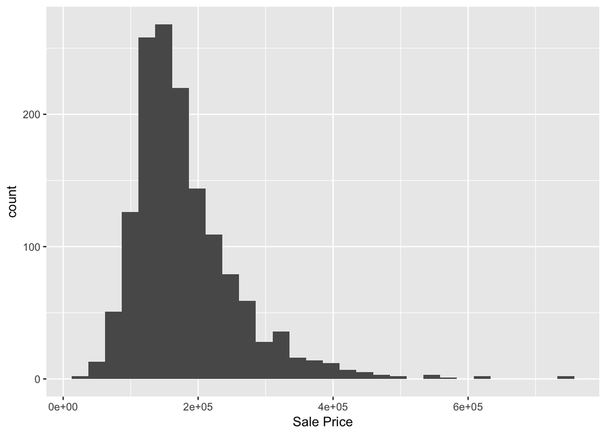

```r
ggplot(data = train.csv , aes(x =SalePrice  )) +
  geom_histogram() +
  xlab('Sale Price')
```

Exercise 2 Visualize the covariation between SalePrice and Neighborhood. • Visualize the covariation between SalePrice and OverallQual.

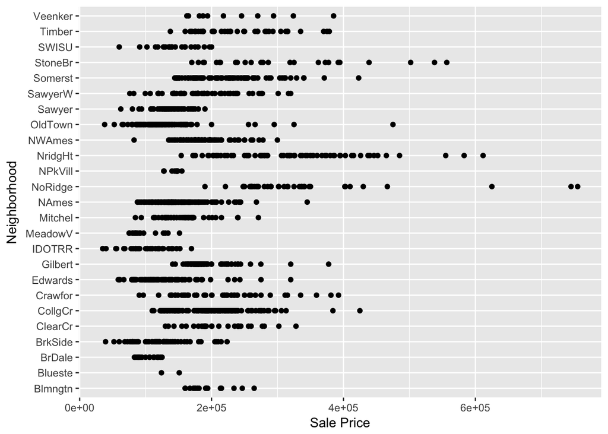

```r
ggplot(data = train.csv , aes(x =SalePrice, y = Neighborhood  )) +
  geom_point() +
  xlab('Sale Price')+
  ylab('Neighborhood')
```

• Visualize the covariation between SalePrice and OverallQual.

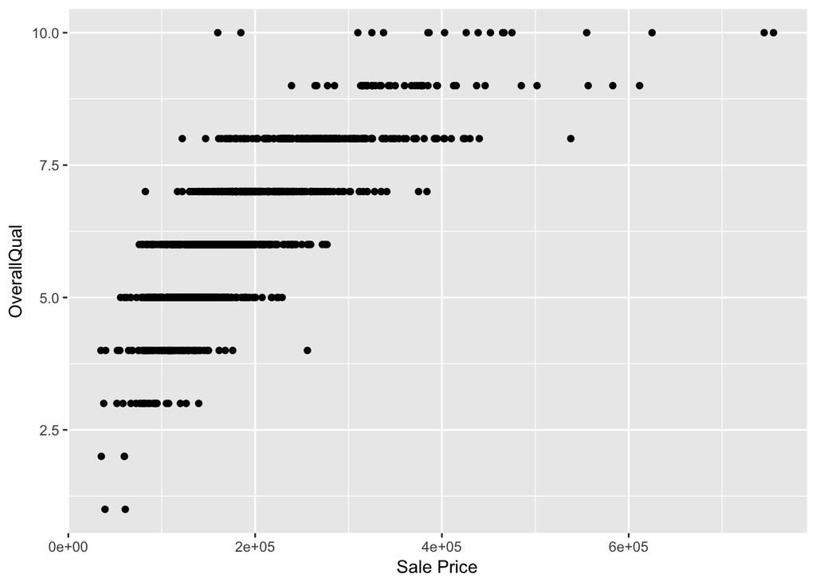

```r
ggplot(data = train.csv , aes(x =SalePrice, y = OverallQual  )) +
  geom_point() +
  xlab('Sale Price')+
  ylab('OverallQual')
```

Exercise 3 Our target is called SalePrice. First, we can fit a simple regression model consisting of only the intercept (the average of SalePrice). Fit the model and then use the broom package to

```r
(SaleP_lm <- lm(formula = SalePrice ~ 1, data = train.csv))
```

```
##
## Call:
## lm(formula = SalePrice ~ 1, data = train.csv)
##
## Coefficients:
## (Intercept)
##      180921
```

• take a look at the coefficient, • compare the coefficient to the average value of SalePrice, and • take a look at the R-squared.

```r
mean(train.csv$SalePrice)
```

```
## [1] 180921.2
```

```r
library(broom)

tidy(SaleP_lm)
```

```
##          term estimate std.error statistic p.value
## 1 (Intercept) 180921.2  2079.105  87.01877       0
```

• take a look at the R-squared.

```r
glance(SaleP_lm)
```

```
##   r.squared adj.r.squared   sigma statistic p.value df    logLik      AIC
## 1         0             0 79442.5        NA      NA  1 -18544.02 37092.04
##        BIC     deviance df.residual
## 1 37102.62 9.207911e+12        1459
```

Exercise 4 Now fit a linear regression model using GrLivArea, OverallQual, and Neighborhood as the features. Don’t forget to look at data_description.txt to understand what these variables mean. Ask yourself these questions before fitting the model: • 4A What kind of relationship will these features have with our target? • 4B Can the relationship be estimated linearly?• 4C Are these good features, given the problem we are trying to solve?

```r
#4A The relationship with the features GrLivArea, OverallQual and Neighborhood has a positive association or relationship with our target SalePrice.
#4B The relationship can be estimated to be linearly.
#4C Yes, there are good features to to help solve the correlation of SalePrice.
diam_mult_lm <- lm(SalePrice ~ GrLivArea + OverallQual+ Neighborhood, data = train.csv)
tidy(diam_mult_lm)
```

```
##                   term    estimate    std.error   statistic      p.value
## 1          (Intercept) -34829.2399 11541.232315 -3.01780945 2.591005e-03
## 2            GrLivArea     55.5645     2.498787 22.23658695 2.375376e-94
## 3          OverallQual  20951.4249  1162.273747 18.02623948 1.238994e-65
## 4  NeighborhoodBlueste -30752.8759 27697.270091 -1.11032155 2.670468e-01
## 5   NeighborhoodBrDale -43358.8812 12978.523255 -3.34081778 8.568095e-04
## 6  NeighborhoodBrkSide -13025.4529 10450.444653 -1.24640179 2.128206e-01
## 7  NeighborhoodClearCr  24575.6351 11569.625542  2.12415129 3.382834e-02
## 8  NeighborhoodCollgCr  11414.3095  9496.581581  1.20193876 2.295858e-01
## 9  NeighborhoodCrawfor  14444.2502 10502.214763  1.37535278 1.692371e-01
## 10 NeighborhoodEdwards -17842.9513  9985.733698 -1.78684430 7.417398e-02
## 11 NeighborhoodGilbert   -892.8796  9954.350137 -0.08969743 9.285402e-01
## 12  NeighborhoodIDOTRR -28178.9866 11135.583978 -2.53053514 1.149517e-02
## 13 NeighborhoodMeadowV -19099.0203 12999.351487 -1.46922870 1.419903e-01
## 14 NeighborhoodMitchel   2030.6121 10555.017277  0.19238359 8.474690e-01
## 15   NeighborhoodNAmes  -4430.0994  9517.290569 -0.46547906 6.416592e-01
## 16 NeighborhoodNoRidge  64642.9895 10939.818250  5.90896375 4.294924e-09
## 17 NeighborhoodNPkVill -17807.1837 15304.007123 -1.16356347 2.447947e-01
## 18 NeighborhoodNridgHt  71587.8398  9994.775058  7.16252635 1.262091e-12
## 19  NeighborhoodNWAmes  -4720.6584 10079.514642 -0.46834183 6.396114e-01
## 20 NeighborhoodOldTown -32080.8775  9863.373223 -3.25252596 1.170466e-03
## 21  NeighborhoodSawyer  -1219.3805 10211.495047 -0.11941254 9.049653e-01
## 22 NeighborhoodSawyerW    303.0986 10264.231736  0.02952960 9.764463e-01
## 23 NeighborhoodSomerst  17766.9637  9829.881193  1.80744440 7.090264e-02
## 24 NeighborhoodStoneBr  69954.4718 11689.508047  5.98438117 2.740136e-09
## 25   NeighborhoodSWISU -36640.1517 11923.592410 -3.07291213 2.159781e-03
## 26  NeighborhoodTimber  29905.8114 10829.232809  2.76158172 5.825641e-03
## 27 NeighborhoodVeenker  47106.8929 14337.857486  3.28549039 1.042655e-03
```

```r
glance(diam_mult_lm)
```

```
##   r.squared adj.r.squared    sigma statistic p.value df    logLik      AIC
## 1 0.7868484      0.782981 37008.52  203.4583       0 27 -17415.62 34887.25
##        BIC     deviance df.residual
## 1 35035.26 1.962681e+12        1433
```

After fitting the model, output the coefficients and the R-squared using the broom package. Answer these questions: • 4D How would you interpret the coefficients on GrLivArea and OverallQual?

The average sale price increase of GrLivArea is $55.6 per every additional above grade (ground) living area square feet.

The average sale price increase of OverallQual is $20,951.42 for a unit of an increase in rates of the overall material and finish of the house

• 4E How would you interpret the coefficient on NeighborhoodBrkSide? That the Neighborhood of BrookSide has an mean sales prices that is 13025.45 less in sales price compared to the base of Neighborhood Bloomington Heights.(not listed neighborhood)

• 4F Are the features significant? We can look at the p valuses to determine the features significant. If the pvalue is low there is significant and when the pvalue is high there is less significant. In GrLivArea the pvalue is 2.375376e-94 which is very low and so this feature is significant to the sale price.

In OverallQual the pvalue is 1.238994e-65 which is very low and so this feature is significant to the sale price.

On the other hand, the pvalue for NeighborhoodBrkSide is 2.128206e-01 and this value is higher and this neighborhood might not have a large significants on the sale price of house in this area.

• 4G Are the features practically significant? The average sale price increase of GrLivArea is $55.6 per every additional above grade (ground) living area square feet. For the GrLivArea $55.6 price for a square area is not practically significant if the it is just a small addition but if you have a lare square foot different in a house or acres of property then the GrLivArea makes a very significant difference in sale price.

The average sale price increase of OverallQual is $20,951.42 for a unit of an increase in rates of the overall material and finish of the house. For the OverallQual feature of $20,951 increase per unit this seems like a very significant freature in the Sale Price.

The Neighborhood features show significant in some neighborhoods (NeighborhoodNoRidge,NeighborhoodStoneBr ) with over $60,000 more in sale price than Neighborhood Bloomington Heights and not much significant in other neighborhoods such as (NeighborhoodSawyerW,NeighborhoodGilbert) with under $1000 in sale price than Neighborhood Bloomington Heights .

• 4H Is the model a good fit? The R square value for the model was 0.7868484 confirms that this was a good fit model to the training set.

Exercise 5 (OPTIONAL - won’t be graded) Feel free to play around with linear regression. Add some other features and see how the model results change.

Exercise 6 One downside of the linear model is that it is sensitive to unusual values because the distance incorporates a squared term. Fit a linear model to the simulated data below (use y as the target and x as the feature), and look at the resulting coefficients and R-squared. Rerun it about 5-6 times to generate different simulated datasets. What do you notice about the model’s coefficient on x and the R-squared values?

```r
# There are a lot of change in the slope, coefficients intercept and R square different simulated datasets.
# the linear model or line moves up and down the y axis a lot and the x variables still show a linear correlation.
# The R squared value stays below 1.0 and varies a lot.
sim1a <- tibble(
x = rep(1:10, each = 3),
y = x * 1.5 + 6 + rt(length(x), df = 2)
)

diam_mult_lm <- lm(y ~ x, data = sim1a)
diam_mult_lm
```

```
##
## Call:
## lm(formula = y ~ x, data = sim1a)
##
## Coefficients:
## (Intercept)            x
##       5.108        1.736
```

```r
tidy(diam_mult_lm)
```

```
##          term estimate std.error statistic      p.value
## 1 (Intercept) 5.108159 2.2129539  2.308299 2.858270e-02
## 2           x 1.736150 0.3566498  4.867940 3.979461e-05
```

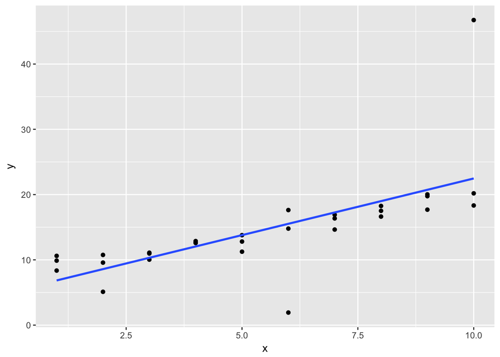

```r
ggplot(sim1a, aes(x=x, y=y)) + geom_point() + geom_smooth(method=lm, se=FALSE)
```

```r
glance(diam_mult_lm)
```

```
##   r.squared adj.r.squared    sigma statistic      p.value df    logLik
## 1 0.4583809     0.4390373 5.610862  23.69684 3.979461e-05  2 -93.27439
##        AIC      BIC deviance df.residual
## 1 192.5488 196.7524 881.4897          28
```